# mnist-handwritten-digits-classification-experiment

## MNIST Handwritten Digits Classification Experiment

This demo shows how you can use SageMaker Experiment Management Python SDK to organize, track, compare, and evaluate your machine learning (ML) model training experiments.

You can track artifacts for experiments, including data sets, algorithms, hyper-parameters, and metrics. Experiments executed on SageMaker such as SageMaker Autopilot jobs and training jobs will be automatically tracked. You can also track artifacts for additional steps within an ML workflow that come before/after model training e.g. data pre-processing or post-training model evaluation.

The APIs also let you search and browse your current and past experiments, compare experiments, and identify best performing models.

Now we will demonstrate these capabilities through an MNIST handwritten digits classification example. The experiment will be organized as follow:

1. Download and prepare the MNIST dataset.
2. Train a Convolutional Neural Network (CNN) Model. Tune the hyper parameter that configures the number of hidden channels in the model. Track the parameter configurations and resulting model accuracy using SageMaker Experiments Python SDK.
3. Finally use the search and analytics capabilities of Python SDK to search, compare and evaluate the performance of all model versions generated from model tuning in Step 2.
4. We will also see an example of tracing the complete linage of a model version i.e. the collection of all the data pre-processing and training configurations and inputs that went into creating that model version.

Make sure you selected `Python 3 (Data Science)` kernel.

### Install Python SDKs

```python
import sys
```

```python
!{sys.executable} -m pip install sagemaker-experiments==0.1.24
```

### Install PyTroch

```python
# pytorch version needs to be the same in both the notebook instance and the training job container
# https://github.com/pytorch/pytorch/issues/25214
!{sys.executable} -m pip install torch==1.1.0
!{sys.executable} -m pip install torchvision==0.3.0
!{sys.executable} -m pip install pillow==6.2.2
!{sys.executable} -m pip install --upgrade sagemaker
```

[output not shown]

### Setup

```python
import time

import boto3
import numpy as np
import pandas as pd
from IPython.display import set_matplotlib_formats
from matplotlib import pyplot as plt
from torchvision import datasets, transforms

import sagemaker
from sagemaker import get_execution_role
from sagemaker.session import Session
from sagemaker.analytics import ExperimentAnalytics

from smexperiments.experiment import Experiment
from smexperiments.trial import Trial
from smexperiments.trial_component import TrialComponent
from smexperiments.tracker import Tracker

set_matplotlib_formats('retina')
```

```python
sess = boto3.Session()
sm = sess.client('sagemaker')
role = get_execution_role()
```

```
WARNING:sagemaker:Couldn't call 'get_role' to get Role ARN from role name AmazonSageMaker-ExecutionRole-20210205T090815 to get Role path.
WARNING:sagemaker:Assuming role was created in SageMaker AWS console, as the name contains `AmazonSageMaker-ExecutionRole`. Defaulting to Role ARN with service-role in path. If this Role ARN is incorrect, please add IAM read permissions to your role or supply the Role Arn directly.
```

### Create a S3 bucket to hold data

```python
# create a s3 bucket to hold data, note that your account might already created a bucket with the same name
account_id = sess.client('sts').get_caller_identity()["Account"]
bucket = 'sagemaker-experiments-{}-{}'.format(sess.region_name, account_id)
prefix = 'mnist'

try:
    if sess.region_name == "us-east-1":
        sess.client('s3').create_bucket(Bucket=bucket)
    else:
        sess.client('s3').create_bucket(Bucket=bucket,
                                        CreateBucketConfiguration={'LocationConstraint': sess.region_name})
except Exception as e:
    print(e)
```

### Dataset

We download the MNIST hand written digits dataset, and then apply transformation on each of the image.

```python
# download the dataset
# this will not only download data to ./mnist folder, but also load and transform (normalize) them
train_set = datasets.MNIST('./mnist', train=True, transform=transforms.Compose([
        transforms.ToTensor(),
        transforms.Normalize((0.1307,), (0.3081,))]),
    download=True)

test_set = datasets.MNIST('./mnist', train=False, transform=transforms.Compose([
        transforms.ToTensor(),
        transforms.Normalize((0.1307,), (0.3081,))]),
    download=False)
```

```
0it [00:00, ?it/s]
```

```
Downloading http://yann.lecun.com/exdb/mnist/train-images-idx3-ubyte.gz to ./mnist/MNIST/raw/train-images-idx3-ubyte.gz
```

```
9920512it [05:03, 31781.33it/s]
```

```
Extracting ./mnist/MNIST/raw/train-images-idx3-ubyte.gz
```

```
32768it [00:00, 303879.56it/s]


0it [00:00, ?it/s]
```

```
Downloading http://yann.lecun.com/exdb/mnist/train-labels-idx1-ubyte.gz to ./mnist/MNIST/raw/train-labels-idx1-ubyte.gz
Extracting ./mnist/MNIST/raw/train-labels-idx1-ubyte.gz
Downloading http://yann.lecun.com/exdb/mnist/t10k-images-idx3-ubyte.gz to ./mnist/MNIST/raw/t10k-images-idx3-ubyte.gz
```

[output not shown]

[output cut: 87 more lines]

[output not shown]

```
Extracting ./mnist/MNIST/raw/t10k-images-idx3-ubyte.gz
Downloading http://yann.lecun.com/exdb/mnist/t10k-labels-idx1-ubyte.gz to ./mnist/MNIST/raw/t10k-labels-idx1-ubyte.gz
```

```
8192it [00:00, 164154.04it/s]
```

```
Extracting ./mnist/MNIST/raw/t10k-labels-idx1-ubyte.gz
Processing...
Done!
```

[output not shown]

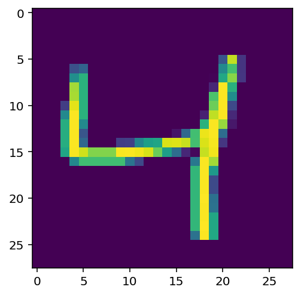

```python
plt.imshow(train_set.data[2].numpy())
```

After transforming the images in the dataset, we upload it to s3.

```python
inputs = sagemaker.Session().upload_data(path='mnist', bucket=bucket, key_prefix=prefix)
print('input spec: {}'.format(inputs))
```

```
input spec: s3://sagemaker-experiments-us-east-1-825222715469/mnist
```

Now lets track the parameters from the data pre-processing step.

```python
with Tracker.create(display_name="Preprocessing", sagemaker_boto_client=sm) as tracker:
    tracker.log_parameters({
        "normalization_mean": 0.1307,
        "normalization_std": 0.3081,
    })
    # we can log the s3 uri to the dataset we just uploaded
    tracker.log_input(name="mnist-dataset", media_type="s3/uri", value=inputs)
```

### Step 1 - Set up the Experiment

Create an experiment to track all the model training iterations. Experiments are a great way to organize your data science work. You can create experiments to organize all your model development work for : [1] a business use case you are addressing (e.g. create experiment named “customer churn prediction”), or [2] a data science team that owns the experiment (e.g. create experiment named “marketing analytics experiment”), or [3] a specific data science and ML project. Think of it as a “folder” for organizing your “files”.

### Create an Experiment

```python
mnist_experiment = Experiment.create(
    experiment_name=f"mnist-hand-written-digits-classification-{int(time.time())}",
    description="Classification of mnist hand-written digits",
    sagemaker_boto_client=sm)
print(mnist_experiment)
```

```
Experiment(sagemaker_boto_client=<botocore.client.SageMaker object at 0x7f457e2a9550>,experiment_name='mnist-hand-written-digits-classification-1615583174',description='Classification of mnist hand-written digits',tags=None,experiment_arn='arn:aws:sagemaker:us-east-1:825222715469:experiment/mnist-ha…
```

### Step 2 - Track Experiment

### Now create a Trial for each training run to track the it's inputs, parameters, and metrics.

While training the CNN model on SageMaker, we will experiment with several values for the number of hidden channel in the model. We will create a Trial to track each training job run. We will also create a TrialComponent from the tracker we created before, and add to the Trial. This will enrich the Trial with the parameters we captured from the data pre-processing stage.

Note the execution of the following code takes a while.

```python
from sagemaker.pytorch import PyTorch, PyTorchModel
```

```python
hidden_channel_trial_name_map = {}
```

If you want to run the following training jobs asynchronously, you may need to increase your resource limit. Otherwise, you can run them sequentially.

```python
preprocessing_trial_component = tracker.trial_component
```

```python
for i, num_hidden_channel in enumerate([2, 5, 10, 20, 32]):
    # create trial
    trial_name = f"cnn-training-job-{num_hidden_channel}-hidden-channels-{int(time.time())}"
    cnn_trial = Trial.create(
        trial_name=trial_name,
        experiment_name=mnist_experiment.experiment_name,
        sagemaker_boto_client=sm,
    )
    hidden_channel_trial_name_map[num_hidden_channel] = trial_name

    # associate the proprocessing trial component with the current trial
    cnn_trial.add_trial_component(preprocessing_trial_component)

    # all input configurations, parameters, and metrics specified in estimator
    # definition are automatically tracked
    estimator = PyTorch(
        py_version='py3',
        entry_point='./mnist.py',
        role=role,
        sagemaker_session=sagemaker.Session(sagemaker_client=sm),
        framework_version='1.1.0',
        instance_count=1,
        instance_type='ml.c4.xlarge',
        hyperparameters={
            'epochs': 2,
            'backend': 'gloo',
            'hidden_channels': num_hidden_channel,
            'dropout': 0.2,
            'kernel_size': 5,
            'optimizer': 'sgd'
        },
        metric_definitions=[
            {'Name':'train:loss', 'Regex':'Train Loss: (.*?);'},
            {'Name':'test:loss', 'Regex':'Test Average loss: (.*?),'},
            {'Name':'test:accuracy', 'Regex':'Test Accuracy: (.*?)%;'}
        ],
        enable_sagemaker_metrics=True
    )

    cnn_training_job_name = "cnn-training-job-{}".format(int(time.time()))

    # Now associate the estimator with the Experiment and Trial
    estimator.fit(
        inputs={'training': inputs},
        job_name=cnn_training_job_name,
        experiment_config={
            "TrialName": cnn_trial.trial_name,
            "TrialComponentDisplayName": "Training",
        },
        wait=True,
    )

    # give it a while before dispatching the next training job
    time.sleep(2)
```

```
INFO:sagemaker.image_uris:Defaulting to the only supported framework/algorithm version: latest.
INFO:sagemaker.image_uris:Ignoring unnecessary instance type: None.
INFO:sagemaker:Creating training-job with name: cnn-training-job-1615583182
```

```
2021-03-12 21:06:23 Starting - Starting the training job...
2021-03-12 21:06:32 Starting - Launching requested ML instancesProfilerReport-1615583182: InProgress
.........
2021-03-12 21:08:14 Starting - Preparing the instances for training......
2021-03-12 21:09:15 Downloading - Downloading input data...
2021-03-12 21:09:52 Training - Training image download completed. Training in progress..bash: cannot set terminal process group (-1): Inappropriate ioctl for device
bash: no job control in this shell
2021-03-12 21:09:54,057 sagemaker-containers INFO     Imported framework sagemaker_pytorch_container.training
2021-03-12 21:09:54,060 sagemaker-containers INFO     No GPUs detected (normal if no gpus installed)
2021-03-12 21:09:54,072 sagemaker_pytorch_container.training INFO     Block until all host DNS lookups succeed.
2021-03-12 21:09:54,073 sagemaker_pytorch_container.training INFO     Invoking user training script.
2021-03-12 21:09:54,524 sagemaker-containers INFO     Module mnist does not provide a setup.py.
Generating setup.py
2021-03-12 21:09:54,524 sagemaker-containers INFO     Generating setup.cfg
2021-03-12 21:09:54,524 sagemaker-containers INFO     Generating MANIFEST.in
2021-03-12 21:09:54,524 sagemaker-containers INFO     Installing module with the following command:
/usr/bin/python -m pip install .
Processing /opt/ml/code
  Running setup.py bdist_wheel for mnist: started
  Running setup.py bdist_wheel for mnist: finished with status 'done'
You are using pip version 18.1, however version 21.0.1 is available.
2021-03-12 21:09:56,679 sagemaker-containers INFO     No GPUs detected (normal if no gpus installed)
2021-03-12 21:09:56,692 sagemaker-containers INFO     Invoking user script

Training Env:

{
    "additional_framework_parameters": {},
    "channel_input_dirs": {
        "training": "/opt/ml/input/data/training"
    },
    "current_host": "algo-1",
    "framework_module": "sagemaker_pytorch_container.training:main",
    "hosts": [
        "algo-1"
    ],
    "hyperparameters": {
        "optimizer": "sgd",
        "hidden_channels": 2,
        "dropout": 0.2,
```

[output cut: 95 more lines]

```
Train Epoch: 2 [25600/60000 (43%)], Train Loss: 0.283167;
Train Epoch: 2 [32000/60000 (53%)], Train Loss: 0.279576;
Train Epoch: 2 [38400/60000 (64%)], Train Loss: 0.341436;
Train Epoch: 2 [44800/60000 (75%)], Train Loss: 0.414407;
Train Epoch: 2 [51200/60000 (85%)], Train Loss: 0.193495;
Train Epoch: 2 [57600/60000 (96%)], Train Loss: 0.157259;
Test Average loss: 0.1158, Test Accuracy: 97%;

Saving the model.
2021-03-12 21:10:39,000 sagemaker-containers INFO     Reporting training SUCCESS

2021-03-12 21:10:52 Uploading - Uploading generated training model
2021-03-12 21:10:52 Completed - Training job completed
Training seconds: 99
Billable seconds: 99
```

```
INFO:sagemaker.image_uris:Defaulting to the only supported framework/algorithm version: latest.
INFO:sagemaker.image_uris:Ignoring unnecessary instance type: None.
INFO:sagemaker:Creating training-job with name: cnn-training-job-1615583468
```

```
2021-03-12 21:11:09 Starting - Starting the training job...
2021-03-12 21:11:34 Starting - Launching requested ML instancesProfilerReport-1615583468: InProgress
......
2021-03-12 21:12:35 Starting - Preparing the instances for training......
2021-03-12 21:13:36 Downloading - Downloading input data
2021-03-12 21:13:36 Training - Downloading the training image..
2021-03-12 21:13:56 Training - Training image download completed. Training in progress.bash: cannot set terminal process group (-1): Inappropriate ioctl for device
bash: no job control in this shell
2021-03-12 21:13:55,536 sagemaker-containers INFO     Imported framework sagemaker_pytorch_container.training
2021-03-12 21:13:55,540 sagemaker-containers INFO     No GPUs detected (normal if no gpus installed)
2021-03-12 21:13:55,553 sagemaker_pytorch_container.training INFO     Block until all host DNS lookups succeed.
2021-03-12 21:13:55,554 sagemaker_pytorch_container.training INFO     Invoking user training script.
2021-03-12 21:13:55,853 sagemaker-containers INFO     Module mnist does not provide a setup.py.
Generating setup.py
2021-03-12 21:13:55,854 sagemaker-containers INFO     Generating setup.cfg
2021-03-12 21:13:55,854 sagemaker-containers INFO     Generating MANIFEST.in
2021-03-12 21:13:55,854 sagemaker-containers INFO     Installing module with the following command:
/usr/bin/python -m pip install .
Processing /opt/ml/code
  Running setup.py bdist_wheel for mnist: started
  Running setup.py bdist_wheel for mnist: finished with status 'done'
You are using pip version 18.1, however version 21.0.1 is available.
2021-03-12 21:13:57,448 sagemaker-containers INFO     No GPUs detected (normal if no gpus installed)
2021-03-12 21:13:57,460 sagemaker-containers INFO     Invoking user script

Training Env:

{
    "additional_framework_parameters": {},
    "channel_input_dirs": {
        "training": "/opt/ml/input/data/training"
    },
    "current_host": "algo-1",
    "framework_module": "sagemaker_pytorch_container.training:main",
    "hosts": [
        "algo-1"
    ],
    "hyperparameters": {
        "optimizer": "sgd",
        "hidden_channels": 5,
```

[output cut: 96 more lines]

```
Train Epoch: 2 [25600/60000 (43%)], Train Loss: 0.272427;
Train Epoch: 2 [32000/60000 (53%)], Train Loss: 0.382764;
Train Epoch: 2 [38400/60000 (64%)], Train Loss: 0.482188;
Train Epoch: 2 [44800/60000 (75%)], Train Loss: 0.203590;
Train Epoch: 2 [51200/60000 (85%)], Train Loss: 0.445356;
Train Epoch: 2 [57600/60000 (96%)], Train Loss: 0.197844;
Test Average loss: 0.1157, Test Accuracy: 96%;

Saving the model.
2021-03-12 21:14:41,491 sagemaker-containers INFO     Reporting training SUCCESS

2021-03-12 21:14:57 Uploading - Uploading generated training model
2021-03-12 21:14:57 Completed - Training job completed
Training seconds: 88
Billable seconds: 88
```

```
INFO:sagemaker.image_uris:Defaulting to the only supported framework/algorithm version: latest.
INFO:sagemaker.image_uris:Ignoring unnecessary instance type: None.
INFO:sagemaker:Creating training-job with name: cnn-training-job-1615583723
```

```
2021-03-12 21:15:24 Starting - Starting the training job...
2021-03-12 21:15:48 Starting - Launching requested ML instancesProfilerReport-1615583723: InProgress
......
2021-03-12 21:16:49 Starting - Preparing the instances for training......
2021-03-12 21:17:50 Downloading - Downloading input data
2021-03-12 21:17:50 Training - Downloading the training image...
2021-03-12 21:18:11 Training - Training image download completed. Training in progress.bash: cannot set terminal process group (-1): Inappropriate ioctl for device
bash: no job control in this shell
2021-03-12 21:18:13,346 sagemaker-containers INFO     Imported framework sagemaker_pytorch_container.training
2021-03-12 21:18:13,349 sagemaker-containers INFO     No GPUs detected (normal if no gpus installed)
2021-03-12 21:18:13,360 sagemaker_pytorch_container.training INFO     Block until all host DNS lookups succeed.
2021-03-12 21:18:13,361 sagemaker_pytorch_container.training INFO     Invoking user training script.
2021-03-12 21:18:21,080 sagemaker-containers INFO     Module mnist does not provide a setup.py.
Generating setup.py
2021-03-12 21:18:21,081 sagemaker-containers INFO     Generating setup.cfg
2021-03-12 21:18:21,081 sagemaker-containers INFO     Generating MANIFEST.in
2021-03-12 21:18:21,081 sagemaker-containers INFO     Installing module with the following command:
/usr/bin/python -m pip install .
Processing /opt/ml/code
  Running setup.py bdist_wheel for mnist: started
  Running setup.py bdist_wheel for mnist: finished with status 'done'
You are using pip version 18.1, however version 21.0.1 is available.
2021-03-12 21:18:23,016 sagemaker-containers INFO     No GPUs detected (normal if no gpus installed)
2021-03-12 21:18:23,028 sagemaker-containers INFO     Invoking user script

Training Env:

{
    "additional_framework_parameters": {},
    "channel_input_dirs": {
        "training": "/opt/ml/input/data/training"
    },
    "current_host": "algo-1",
    "framework_module": "sagemaker_pytorch_container.training:main",
    "hosts": [
        "algo-1"
    ],
    "hyperparameters": {
        "optimizer": "sgd",
        "hidden_channels": 10,
```

[output cut: 96 more lines]

```
Train Epoch: 2 [25600/60000 (43%)], Train Loss: 0.376957;
Train Epoch: 2 [32000/60000 (53%)], Train Loss: 0.412861;
Train Epoch: 2 [38400/60000 (64%)], Train Loss: 0.200810;
Train Epoch: 2 [44800/60000 (75%)], Train Loss: 0.233049;

2021-03-12 21:19:26 Uploading - Uploading generated training model
2021-03-12 21:19:26 Completed - Training job completed
Train Epoch: 2 [51200/60000 (85%)], Train Loss: 0.319483;
Train Epoch: 2 [57600/60000 (96%)], Train Loss: 0.210030;
Test Average loss: 0.1060, Test Accuracy: 97%;

Saving the model.
2021-03-12 21:19:15,825 sagemaker-containers INFO     Reporting training SUCCESS
Training seconds: 109
Billable seconds: 109
```

```
INFO:sagemaker.image_uris:Defaulting to the only supported framework/algorithm version: latest.
INFO:sagemaker.image_uris:Ignoring unnecessary instance type: None.
INFO:sagemaker:Creating training-job with name: cnn-training-job-1615583979
```

```
2021-03-12 21:19:39 Starting - Starting the training job...
2021-03-12 21:20:05 Starting - Launching requested ML instancesProfilerReport-1615583979: InProgress
.........
2021-03-12 21:21:26 Starting - Preparing the instances for training...
2021-03-12 21:22:08 Downloading - Downloading input data...
2021-03-12 21:22:26 Training - Downloading the training image..bash: cannot set terminal process group (-1): Inappropriate ioctl for device
bash: no job control in this shell
2021-03-12 21:22:48,633 sagemaker-containers INFO     Imported framework sagemaker_pytorch_container.training
2021-03-12 21:22:48,636 sagemaker-containers INFO     No GPUs detected (normal if no gpus installed)
2021-03-12 21:22:48,647 sagemaker_pytorch_container.training INFO     Block until all host DNS lookups succeed.
2021-03-12 21:22:48,648 sagemaker_pytorch_container.training INFO     Invoking user training script.
2021-03-12 21:22:48,920 sagemaker-containers INFO     Module mnist does not provide a setup.py.
Generating setup.py
2021-03-12 21:22:48,920 sagemaker-containers INFO     Generating setup.cfg
2021-03-12 21:22:48,921 sagemaker-containers INFO     Generating MANIFEST.in
2021-03-12 21:22:48,921 sagemaker-containers INFO     Installing module with the following command:
/usr/bin/python -m pip install .
Processing /opt/ml/code
  Running setup.py bdist_wheel for mnist: started
  Running setup.py bdist_wheel for mnist: finished with status 'done'
You are using pip version 18.1, however version 21.0.1 is available.
2021-03-12 21:22:50,677 sagemaker-containers INFO     No GPUs detected (normal if no gpus installed)
2021-03-12 21:22:50,690 sagemaker-containers INFO     Invoking user script

Training Env:

{
    "additional_framework_parameters": {},
    "channel_input_dirs": {
        "training": "/opt/ml/input/data/training"
    },
    "current_host": "algo-1",
    "framework_module": "sagemaker_pytorch_container.training:main",
    "hosts": [
        "algo-1"
    ],
    "hyperparameters": {
        "optimizer": "sgd",
        "hidden_channels": 20,
        "dropout": 0.2,
```

[output cut: 96 more lines]

```
Train Epoch: 2 [25600/60000 (43%)], Train Loss: 0.451251;
Train Epoch: 2 [32000/60000 (53%)], Train Loss: 0.263621;
Train Epoch: 2 [38400/60000 (64%)], Train Loss: 0.151691;
Train Epoch: 2 [44800/60000 (75%)], Train Loss: 0.375438;
Train Epoch: 2 [51200/60000 (85%)], Train Loss: 0.332934;
Train Epoch: 2 [57600/60000 (96%)], Train Loss: 0.227200;
Test Average loss: 0.0965, Test Accuracy: 97%;

Saving the model.
2021-03-12 21:23:52,579 sagemaker-containers INFO     Reporting training SUCCESS

2021-03-12 21:24:08 Uploading - Uploading generated training model
2021-03-12 21:24:08 Completed - Training job completed
Training seconds: 114
Billable seconds: 114
```

```
INFO:sagemaker.image_uris:Defaulting to the only supported framework/algorithm version: latest.
INFO:sagemaker.image_uris:Ignoring unnecessary instance type: None.
INFO:sagemaker:Creating training-job with name: cnn-training-job-1615584264
```

```
2021-03-12 21:24:24 Starting - Starting the training job...
2021-03-12 21:24:51 Starting - Launching requested ML instancesProfilerReport-1615584264: InProgress
.........
2021-03-12 21:26:12 Starting - Preparing the instances for training......
2021-03-12 21:27:19 Downloading - Downloading input data
2021-03-12 21:27:19 Training - Downloading the training image..
2021-03-12 21:27:53 Training - Training image download completed. Training in progress.bash: cannot set terminal process group (-1): Inappropriate ioctl for device
bash: no job control in this shell
2021-03-12 21:27:41,563 sagemaker-containers INFO     Imported framework sagemaker_pytorch_container.training
2021-03-12 21:27:41,566 sagemaker-containers INFO     No GPUs detected (normal if no gpus installed)
2021-03-12 21:27:41,577 sagemaker_pytorch_container.training INFO     Block until all host DNS lookups succeed.
2021-03-12 21:27:41,578 sagemaker_pytorch_container.training INFO     Invoking user training script.
2021-03-12 21:27:42,060 sagemaker-containers INFO     Module mnist does not provide a setup.py.
Generating setup.py
2021-03-12 21:27:42,060 sagemaker-containers INFO     Generating setup.cfg
2021-03-12 21:27:42,061 sagemaker-containers INFO     Generating MANIFEST.in
2021-03-12 21:27:42,061 sagemaker-containers INFO     Installing module with the following command:
/usr/bin/python -m pip install .
Processing /opt/ml/code
  Running setup.py bdist_wheel for mnist: started
  Running setup.py bdist_wheel for mnist: finished with status 'done'
You are using pip version 18.1, however version 21.0.1 is available.
2021-03-12 21:27:44,067 sagemaker-containers INFO     No GPUs detected (normal if no gpus installed)
2021-03-12 21:27:44,079 sagemaker-containers INFO     Invoking user script

Training Env:

{
    "additional_framework_parameters": {},
    "channel_input_dirs": {
        "training": "/opt/ml/input/data/training"
    },
    "current_host": "algo-1",
    "framework_module": "sagemaker_pytorch_container.training:main",
    "hosts": [
        "algo-1"
    ],
    "hyperparameters": {
        "optimizer": "sgd",
        "hidden_channels": 32,
```

[output cut: 96 more lines]

```
Train Epoch: 2 [25600/60000 (43%)], Train Loss: 0.200822;
Train Epoch: 2 [32000/60000 (53%)], Train Loss: 0.377310;
Train Epoch: 2 [38400/60000 (64%)], Train Loss: 0.227790;
Train Epoch: 2 [44800/60000 (75%)], Train Loss: 0.642007;

2021-03-12 21:28:57 Uploading - Uploading generated training modelTrain Epoch: 2 [51200/60000 (85%)], Train Loss: 0.365126;
Train Epoch: 2 [57600/60000 (96%)], Train Loss: 0.101494;
Test Average loss: 0.1012, Test Accuracy: 97%;

Saving the model.
2021-03-12 21:28:53,770 sagemaker-containers INFO     Reporting training SUCCESS

2021-03-12 21:29:14 Completed - Training job completed
Training seconds: 120
Billable seconds: 120
```

### Compare the model training runs for an experiment

Now we will use the analytics capabilities of Python SDK to query and compare the training runs for identifying the best model produced by our experiment. You can retrieve trial components by using a search expression.

### Some Simple Analyses

```python
search_expression = {
    "Filters":[
        {
            "Name": "DisplayName",
            "Operator": "Equals",
            "Value": "Training",
        }
    ],
}
```

```python
trial_component_analytics = ExperimentAnalytics(
    sagemaker_session=Session(sess, sm),
    experiment_name=mnist_experiment.experiment_name,
    search_expression=search_expression,
    sort_by="metrics.test:accuracy.max",
    sort_order="Descending",
    metric_names=['test:accuracy'],
    parameter_names=['hidden_channels', 'epochs', 'dropout', 'optimizer']
)
```

```python
trial_component_analytics.dataframe()
```

[output not shown]

5 rows × 21 columns

To isolate and measure the impact of change in hidden channels on model accuracy, we vary the number of hidden channel and fix the value for other hyperparameters.

Next let's look at an example of tracing the lineage of a model by accessing the data tracked by SageMaker Experiments for `cnn-training-job-2-hidden-channels` trial

```python
lineage_table = ExperimentAnalytics(
    sagemaker_session=Session(sess, sm),
    search_expression={
        "Filters":[{
            "Name": "Parents.TrialName",
            "Operator": "Equals",
            "Value": hidden_channel_trial_name_map[2]
        }]
    },
    sort_by="CreationTime",
    sort_order="Ascending",
)
```

```python
lineage_table.dataframe()
```

|  | TrialComponentName | DisplayName | normalization_mean | normalization_std | mnist-dataset - MediaType | mnist-dataset - Value | Trials | Experiments | SourceArn | SageMaker.ImageUri | ... | train:loss - Avg | train:loss - StdDev | train:loss - Last | train:loss - Count | training - MediaType | training - Value | SageMaker.DebugHookOutput - MediaType | SageMaker.DebugHookOutput - Value | SageMaker.ModelArtifact - MediaType | SageMaker.ModelArtifact - Value |
| --- | --- | --- | --- | --- | --- | --- | --- | --- | --- | --- | --- | --- | --- | --- | --- | --- | --- | --- | --- | --- | --- |
| 0 | TrialComponent-2021-03-12-210608-hmkt | Preprocessing | 0.1307 | 0.3081 | s3/uri | s3://sagemaker-experiments-us-east-1-825222715... | [cnn-training-job-5-hidden-channels-1615583468... | [mnist-hand-written-digits-classification-1615... | NaN | NaN | ... | NaN | NaN | NaN | NaN | NaN | NaN | NaN | NaN | NaN | NaN |
| 1 | cnn-training-job-1615583182-aws-training-job | Training | NaN | NaN | NaN | NaN | [cnn-training-job-2-hidden-channels-1615583182] | [mnist-hand-written-digits-classification-1615... | arn:aws:sagemaker:us-east-1:825222715469:train... | 520713654638.dkr.ecr.us-east-1.amazonaws.com/s... | ... | 0.456703 | 0.352488 | 0.157259 | 18.0 | NaN | s3://sagemaker-experiments-us-east-1-825222715... | NaN | s3://sagemaker-us-east-1-825222715469/ | NaN | s3://sagemaker-us-east-1-825222715469/cnn-trai... |

2 rows × 48 columns

## Deploy endpoint for the best training-job / trial component

Now we'll take the best (as sorted) and create an endpoint for it.

```python
#Pulling best based on sort in the analytics/dataframe so first is best....
best_trial_component_name = trial_component_analytics.dataframe().iloc[0]['TrialComponentName']
best_trial_component = TrialComponent.load(best_trial_component_name)

model_data = best_trial_component.output_artifacts['SageMaker.ModelArtifact'].value
env = {'hidden_channels': str(int(best_trial_component.parameters['hidden_channels'])),
       'dropout': str(best_trial_component.parameters['dropout']),
       'kernel_size': str(int(best_trial_component.parameters['kernel_size']))}
model = PyTorchModel(
            model_data,
            role,
            './mnist.py',
            py_version='py3',
            env=env,
            sagemaker_session=sagemaker.Session(sagemaker_client=sm),
            framework_version='1.1.0',
            name=best_trial_component.trial_component_name)

predictor = model.deploy(
    instance_type='ml.m5.xlarge',
    initial_instance_count=1)
```

```
INFO:sagemaker:Creating model with name: cnn-training-job-1615584264-aws-training-job
INFO:sagemaker:Creating endpoint with name cnn-training-job-1615584264-aws-trainin-2021-03-12-21-29-56-442
```

```
-------------!
```

## Cleanup

Once we're doing don't forget to clean up the endpoint to prevent unnecessary billing.

> Trial components can exist independent of trials and experiments. You might want keep them if you plan on further exploration. If so, comment out tc.delete()

```python
predictor.delete_endpoint()
```

```python
mnist_experiment.delete_all(action='--force')
```

## Contact

Submit any questions or issues to https://github.com/aws/sagemaker-experiments/issues or mention @aws/sagemakerexperimentsadmin